# Project 2: NYC & Crime

Mary Anna Kivenson

3/10/2019

This project will tidy the following datasets to analyze stop-and-frisk data, demographics information, and crime rates in New York City and in the United States:

- [Stop and Frisk HTML Data from the ACLU](https://www.nyclu.org/en/stop-and-frisk-data)
- [NYC Demographic Wide Data from the 2010 Census](https://www1.nyc.gov/site/planning/data-maps/nyc-population/census-2010.page)
- [Annual Crime in Large Local Agencies Wide Data](https://www.ucrdatatool.gov/Search/Crime/Local/TrendsInOneVarStepTwoLarge.cfm)

The following packages will be used:

- library(stringr)
- library(dplyr)
- library(plyr)
- library(magrittr)
- library(DT)
- library(tidyr)
- library(ggplot2)
- library(zoo)
- library(janitor)
- library(gganimate)
- library(gifski)
- library(png)
- library(gridExtra)
- library(RColorBrewer)

## Dataset 1: Stop and Frisk Data

The ACLU provides annual [Stop and Frisk Data](https://www.nyclu.org/en/stop-and-frisk-data) that summarizes NYPD stops by year, outcome, race, and age. The code below extracts the ACLU html webpage as a string, then uses regular expressions to extract only the report summary (excluding other html on the page, such as links and charts). Finally, ldply is used to split the list by element and to create a dataframe.

### Raw HTML Data Preview

This is a 10 line preview of the HTML data extracted from the ACLU website. It is mostly comprised of unneccesary information, and the strings that are useful are not included in the preview.

```r
#Preview of html Stop-and-Frisk Data
head(readLines("https://www.nyclu.org/en/stop-and-frisk-data"), n=10)
```

```
##  [1] "<!DOCTYPE html>"
##  [2] "<!--[if IEMobile 7]><html class=\"iem7\"  lang=\"en\" dir=\"ltr\"><![endif]-->"
##  [3] "<!--[if lte IE 6]><html class=\"lt-ie9 lt-ie8 lt-ie7\"  lang=\"en\" dir=\"ltr\"><![endif]-->"
##  [4] "<!--[if (IE 7)&(!IEMobile)]><html class=\"lt-ie9 lt-ie8\"  lang=\"en\" dir=\"ltr\"><![endif]-->"
##  [5] "<!--[if IE 8]><html class=\"lt-ie9\"  lang=\"en\" dir=\"ltr\"><![endif]-->"
##  [6] "<!--[if IE 9]><html class=\"lt-ie10\"  lang=\"en\" dir=\"ltr\"><![endif]-->"
##  [7] "<!--[if (gte IE 10)|(gt IEMobile 7)]><!--><html  lang=\"en\" dir=\"ltr\" prefix=\"fb: http://ogp.me/ns/fb# og: http://ogp.me/ns# article: http://ogp.me/ns/article# book: http://ogp.me/ns/book# profile: http://ogp.me/ns/profile# video: http://ogp.me/ns/video# product: http://ogp.me/ns/produc…
##  [8] ""
##  [9] "<head>"
## [10] "  <meta charset=\"utf-8\" />"
```

### Extract Relevant Strings

Inspecting the elements of the html webpage reveals that the necessary strings are list elements within an unordered list:

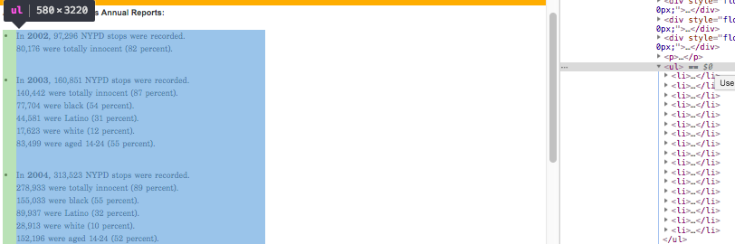

There are also list elements that contain links, so we remove those and then extract the remaining list elements. This returns only the strings that we are interested in.

```r
#Extract relevant strings from html data
stop_frisk_data <- readLines("https://www.nyclu.org/en/stop-and-frisk-data") %>%
  str_remove_all("<(li)><(a href).+(<\\/a>)<\\/\\1>") %>%  #removes all list elements that contain links
  str_extract(pattern = "<(li)>.+<\\/\\1>") %>%  #extracts all remaining list elements
  na.omit() %>% #removes NA values
  `attributes<-`(NULL) #removes attributes created by na.omit
head(stop_frisk_data, n=3, options = list(scrollX = FALSE))
```

```
## [1] "<li>In <strong>2002</strong>, 97,296 NYPD stops were recorded.<br />80,176 were totally innocent (82 percent).<br /> </li>"
## [2] "<li>In <strong>2003</strong>, 160,851 NYPD stops were recorded.<br />140,442 were totally innocent (87 percent).<br />77,704 were black (54 percent).<br />44,581 were Latino (31 percent).<br />17,623 were white (12 percent).<br />83,499 were aged 14-24 (55 percent).<br /> </li>"
## [3] "<li>In <strong>2004</strong>, 313,523 NYPD stops were recorded.<br />278,933 were totally innocent (89 percent).<br />155,033 were black (55 percent).<br />89,937 were Latino (32 percent).<br />28,913 were white (10 percent).<br />152,196 were aged 14-24 (52 percent).<br /> </li>"
```

### Transform Strings into a Dataframe

To transform a list of strings into a dataframe, we first use regular expressions to extract all years, numbers, and percentages from the strings. Next, we use ldply to separate the contents of the list into a matrix. Finally, we name and classify the columns based on the figures the numbers represent.

```r
#Transform strings into a dataframe
stop_frisk_data %<>%
  str_extract_all(pattern="([0-9]){4}|([0-9])+(?= percent)|([0-9]+.[0-9]+)") %>% #extract all years, numbers, and percentages from the strings
  ldply(rbind) %>% #transform the list into a matrix
  rename(c("1"="year","2"="tot_stop","3"="tot_innocent","4"="pct_innocent","5"="tot_black","6"="pct_black","7"="tot_hispanic","8"="pct_hispanic","9"="tot_white","10"="pct_white","11"="tot_14-24","12"="pct_14-24"))

#Change data types of totals and percentages to numeric
for (i in 2:12){
  stop_frisk_data[,i] %<>%
  str_replace("[[:punct:]]" , "")
  stop_frisk_data[,i] = as.numeric(as.character(stop_frisk_data[,i]))
}
datatable(stop_frisk_data,options = list(scrollX = TRUE))
```

|  | year | tot_stop | tot_innocent | pct_innocent | tot_black | pct_black | tot_hispanic | pct_hispanic | tot_white | pct_white | tot_14-24 | pct_14-24 | 13 |
| --- | --- | --- | --- | --- | --- | --- | --- | --- | --- | --- | --- | --- | --- |
| 1 | 2002 | 97296 | 80176 | 82 |  |  |  |  |  |  |  |  |  |
| 2 | 2003 | 160851 | 140442 | 87 | 77704 | 54 | 44581 | 31 | 17623 | 12 | 83499 | 1424 | 55 |
| 3 | 2004 | 313523 | 278933 | 89 | 155033 | 55 | 89937 | 32 | 28913 | 10 | 152196 | 1424 | 52 |
| 4 | 2005 | 398191 | 352348 | 89 | 196570 | 54 | 115088 | 32 | 40713 | 11 | 189854 | 1424 | 51 |
| 5 | 2006 | 506491 | 457163 | 90 | 267468 | 53 | 147862 | 29 | 53500 | 11 | 247691 | 1424 | 50 |
| 6 | 2007 | 472096 | 410936 | 87 | 243766 | 54 | 141868 | 31 | 52887 | 12 | 223783 | 1424 | 48 |
| 7 | 2008 | 540302 | 474387 | 88 | 275588 | 53 | 168475 | 32 | 57650 | 11 | 263408 | 1424 | 49 |
| 8 | 2009 | 581168 | 510742 | 88 | 310611 | 55 | 180055 | 32 | 53601 | 10 | 289602 | 1424 | 50 |
| 9 | 2010 | 601285 | 518849 | 86 | 315083 | 54 | 189326 | 33 | 54810 | 9 | 295902 | 1424 | 49 |
| 10 | 2011 | 685724 | 605328 | 88 | 350743 | 53 | 223740 | 34 | 61805 | 9 | 341581 | 1424 | 51 |

[output cut: 7 more lines]

### Transform Dataframe into Long Format

To be able to analyze NYPD stops by race, we can subset the dataframe and then transform it into long format using the gather function.

```r
#Subset of NYPD stops by race totals
totals_frisk_long <- stop_frisk_data %>%
  select(c(1,5,7,9)) %>% #subset dataframe
  gather("race", "total", 2:4) #transform into long format
datatable(totals_frisk_long)
```

|  | year | race | total |
| --- | --- | --- | --- |
| 1 | 2002 | tot_black |  |
| 2 | 2003 | tot_black | 77704 |
| 3 | 2004 | tot_black | 155033 |
| 4 | 2005 | tot_black | 196570 |
| 5 | 2006 | tot_black | 267468 |
| 6 | 2007 | tot_black | 243766 |
| 7 | 2008 | tot_black | 275588 |
| 8 | 2009 | tot_black | 310611 |
| 9 | 2010 | tot_black | 315083 |
| 10 | 2011 | tot_black | 350743 |

[output cut: 41 more lines]

```r
#Subset of NYPD stops by race percentages
pct_frisk_long <- stop_frisk_data %>%
  select(c(1,6,8,10)) %>% #subset dataframe
  gather("race", "pct", 2:4) #transform into long format
datatable(pct_frisk_long)
```

|  | year | race | pct |
| --- | --- | --- | --- |
| 1 | 2002 | pct_black |  |
| 2 | 2003 | pct_black | 54 |
| 3 | 2004 | pct_black | 55 |
| 4 | 2005 | pct_black | 54 |
| 5 | 2006 | pct_black | 53 |
| 6 | 2007 | pct_black | 54 |
| 7 | 2008 | pct_black | 53 |
| 8 | 2009 | pct_black | 55 |
| 9 | 2010 | pct_black | 54 |
| 10 | 2011 | pct_black | 53 |

[output cut: 41 more lines]

### Analyze Stop-and-Frisk Statistics

Now that we were able to tidy the HTML strings into a dataframe, we can plot summaries of the data.

#### NYPD Stops by Year

This table shows that stop-and-frisk started in 2002 and reached its peak in 2011. Although numbers dropped off significantly, the practice still exists.

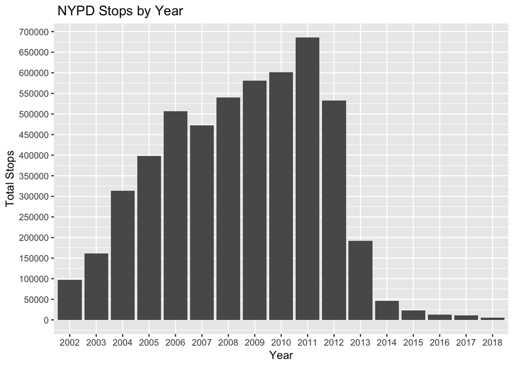

```r
ggplot(stop_frisk_data, aes(year, tot_stop)) + geom_bar(stat = "identity") + labs(title =" NYPD Stops by Year", x = "Year") + scale_y_continuous(name = "Total Stops", breaks = seq(0,700000,50000))
```

#### Annual NYPD Stops by Race

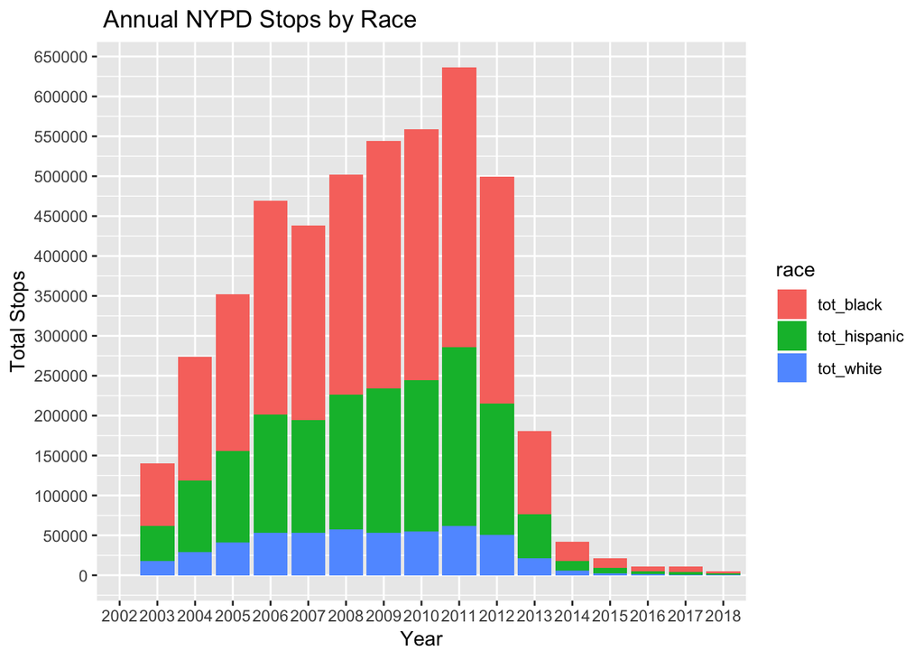

```r
ggplot(totals_frisk_long, aes(year, total)) + geom_bar(stat = "identity", aes(fill = race)) + labs(title =" Annual NYPD Stops by Race", x = "Year") + scale_y_continuous(name = "Total Stops", breaks = seq(0,700000,50000))
```

## Dataset 2: NYC 2010 Demographics

### Import Data

The first step is to import the NYC demographics data as a csv file.

```r
nyc_demographic <- read.csv(file = "https://github.com/mkivenson/Data-Acquisition-and-Management/raw/master/Project%202/NYCDemographics.csv", skip = 7, header = FALSE)
datatable(nyc_demographic,options = list(scrollX = TRUE))
```

|  | V1 | V2 | V3 | V4 | V5 | V6 | V7 | V8 | V9 | V10 | V11 |
| --- | --- | --- | --- | --- | --- | --- | --- | --- | --- | --- | --- |
| 1 | Total Population: |  |  |  |  |  |  |  |  |  |  |
| 2 |  | New York City | 8,175,133 | 2,722,904 | 1,861,295 | 17,427 | 1,028,119 | 2,795 | 57,841 | 148,676 | 2,336,076 |
| 3 |  | Bronx | 1,385,108 | 151,209 | 416,695 | 3,460 | 47,335 | 398 | 8,636 | 15,962 | 741,413 |
| 4 |  | Brooklyn | 2,504,700 | 893,306 | 799,066 | 4,638 | 260,129 | 633 | 10,633 | 40,010 | 496,285 |
| 5 |  | Manhattan | 1,585,873 | 761,493 | 205,340 | 2,144 | 177,624 | 533 | 5,205 | 29,957 | 403,577 |
| 6 |  | Queens | 2,230,722 | 616,727 | 395,881 | 6,490 | 508,334 | 1,094 | 32,339 | 56,107 | 613,750 |
| 7 |  | Staten Island | 468,730 | 300,169 | 44,313 | 695 | 34,697 | 137 | 1,028 | 6,640 | 81,051 |
| 8 |  |  |  |  |  |  |  |  |  |  |  |
| 9 |  | New York City | 100.0 | 33.3 | 22.8 | 0.2 | 12.6 | 0.0 | 0.7 | 1.8 | 28.6 |
| 10 |  | Bronx | 100.0 | 10.9 | 30.1 | 0.2 | 3.4 | 0.0 | 0.6 | 1.2 | 53.5 |

[output cut: 2096 more lines]

### Tidy Demographics Dataframe

The original dataset needs to be tidied, which involves: renaming columns, removing empty rows, changing datatypes, populating empty column values, and removing unneeded data.

```r
nyc_demographic %<>%
  rename(c("V1"="Type","V2"="Borough","V3"="tot_pop","V4"="tot_white","V5"="tot_black","V6"="tot_AI/AN","V7"="tot_asian","V8"="tot_NH/PI","V9"="tot_other","V10"="tot_two","V11"="tot_hispanic")) #rename columns

nyc_demographic <- nyc_demographic[!apply(nyc_demographic == "", 1, all),] #remove empty rows

#Change data types of totals and percentages to numeric
for (i in 3:11){
  nyc_demographic[,i] %<>%
  str_replace_all("," , "")
  nyc_demographic[,i] = as.numeric(as.character(nyc_demographic[,i]))
}

#Populate Type column
nyc_demographic$Type[nyc_demographic$Type == ""] <- NA #replace empty values in the type column with NA values
nyc_demographic$Type <- na.locf(nyc_demographic$Type) #fill NA values from the type column with the previous valid value
nyc_demographic <- nyc_demographic[!(nyc_demographic$Borough==""), ] #remove rows without a borough
```

### Transform Demographics Dataframe

The next step is to transform the dataset by deleting total population row and columns (we can plot the totals as the sum of subtotals).

**Subset of NYC Demographics: Totals**

```r
totals_nyc_long <- nyc_demographic %>%
  filter(tot_pop > 100) %>% #filter for counts only (remove percentages)
  select(c(-3)) %>% #subset dataframe - remove total population column
  subset(Type != "Total Population:") %>% #subset dataframe - remove total population rows
  gather("race", "total", 3:10) #transform into long format
datatable(totals_nyc_long)
```

|  | Type | Borough | race | total |
| --- | --- | --- | --- | --- |
| 1 | Under 18 Years: | New York City | tot_white | 438485 |
| 2 | Under 18 Years: | Bronx | tot_white | 21004 |
| 3 | Under 18 Years: | Brooklyn | tot_white | 191273 |
| 4 | Under 18 Years: | Manhattan | tot_white | 77556 |
| 5 | Under 18 Years: | Queens | tot_white | 89636 |
| 6 | Under 18 Years: | Staten Island | tot_white | 59016 |
| 7 | 18 Years and Over: | New York City | tot_white | 2284419 |
| 8 | 18 Years and Over: | Bronx | tot_white | 130205 |
| 9 | 18 Years and Over: | Brooklyn | tot_white | 702033 |
| 10 | 18 Years and Over: | Manhattan | tot_white | 683937 |

[output cut: 86 more lines]

**Subset of NYC Demographics: Percentages**

```r
pct_nyc_long <- nyc_demographic %>%
  filter(tot_pop < 100) %>% #filter for percentages only (remove counts)
  select(c(-3)) %>% #subset dataframe - remove total population column
  subset(Type != "Total Population:") %>% #subset dataframe - remove total population rows
  gather("race", "pct", 3:10) #transform into long format
datatable(pct_nyc_long)
```

|  | Type | Borough | race | pct |
| --- | --- | --- | --- | --- |
| 1 | Under 18 Years: | Bronx | tot_white | 4.8 |
| 2 | Under 18 Years: | Brooklyn | tot_white | 43.6 |
| 3 | Under 18 Years: | Manhattan | tot_white | 17.7 |
| 4 | Under 18 Years: | Queens | tot_white | 20.4 |
| 5 | Under 18 Years: | Staten Island | tot_white | 13.5 |
| 6 | 18 Years and Over: | Bronx | tot_white | 5.7 |
| 7 | 18 Years and Over: | Brooklyn | tot_white | 30.7 |
| 8 | 18 Years and Over: | Manhattan | tot_white | 29.9 |
| 9 | 18 Years and Over: | Queens | tot_white | 23.1 |
| 10 | 18 Years and Over: | Staten Island | tot_white | 10.6 |

[output cut: 70 more lines]

### Analyze NYC Demographics

Now that we were able to tidy the semi-structured data into a long dataframe, we can plot summaries of the data.

#### Race

This table shows an overview of the overall NYC population by race.

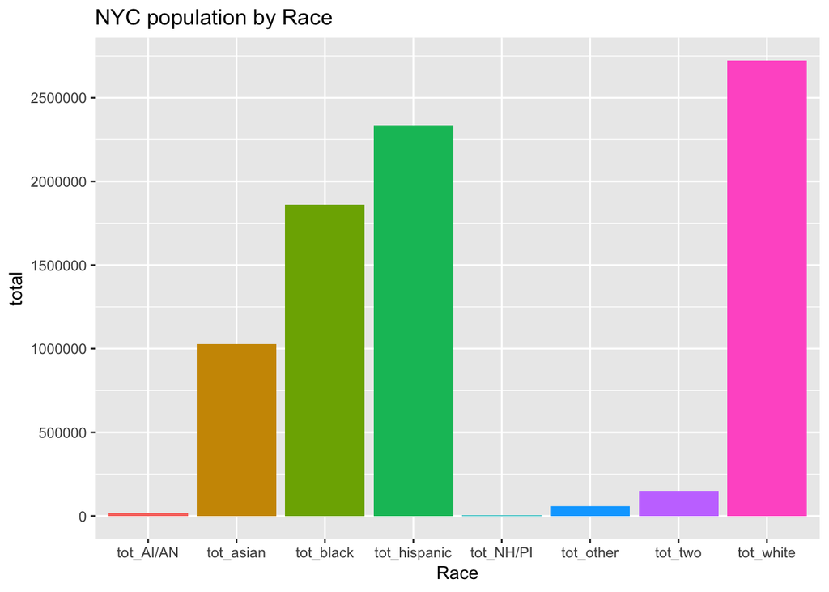

```r
totals_nyc_long2 <- totals_nyc_long %>%
  filter(Borough != "New York City")
ggplot(totals_nyc_long2, aes(race, total)) + geom_bar(stat = "identity", aes(fill = race)) + labs(title ="NYC population by Race", x = "Race") + scale_y_continuous(breaks = seq(0,3000000,500000)) + guides(fill = "none")
```

#### Age

This table shows an overview of the overall NYC population by race, broken down by age (over 18 and under 18).

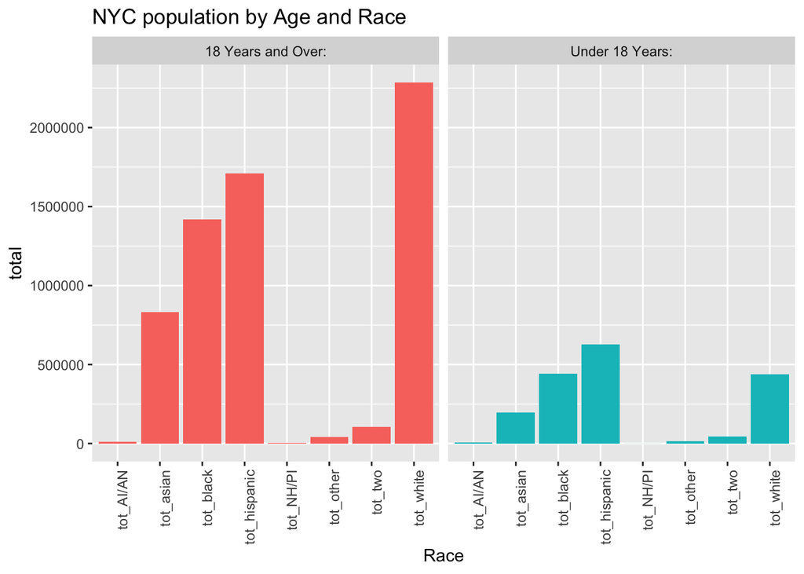

```r
ggplot(totals_nyc_long2, aes(race, total)) + geom_bar(stat = "identity", aes(fill = Type)) + facet_grid(.~Type) + theme(axis.text.x = element_text(angle = 90, hjust = 1)) + labs(title ="NYC population by Age and Race", x = "Race") + guides(fill = "none")
```

#### Borough

This table shows an overview of the overall NYC population by borough and race.

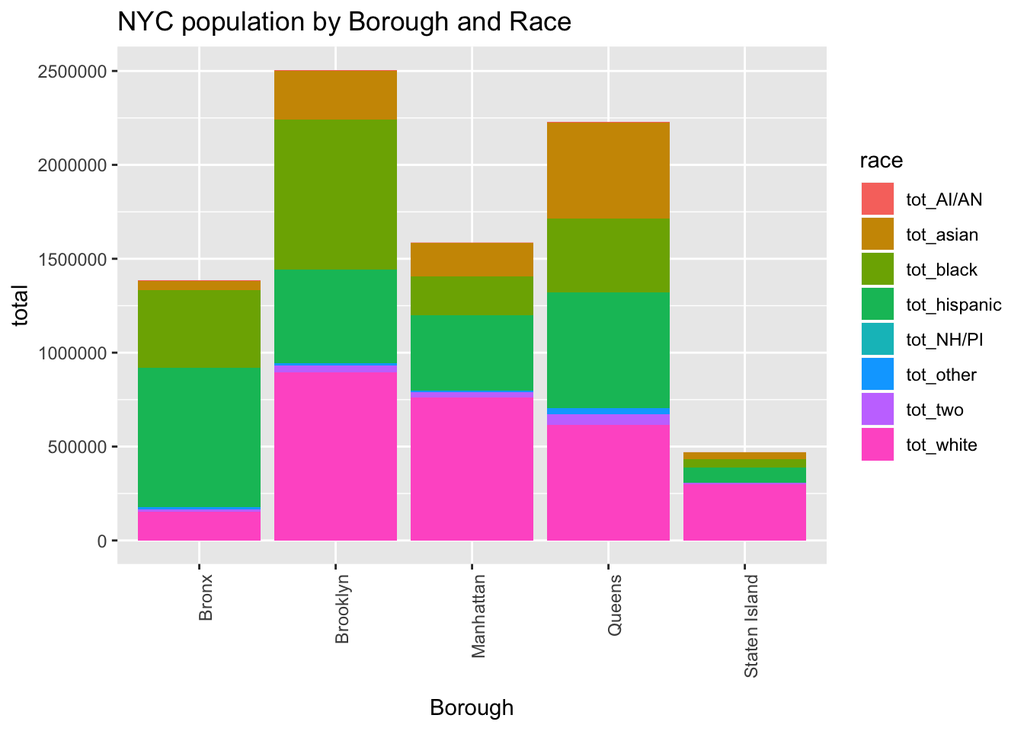

```r
ggplot(totals_nyc_long2, aes(Borough, total)) + geom_bar(stat = "identity", aes(fill = race))  + theme(axis.text.x = element_text(angle = 90, hjust = 1)) + labs(title ="NYC population by Borough and Race", x = "Borough")
```

#### Stop-and-Frisk

```r
pop <- aggregate(totals_nyc_long$total, list(totals_nyc_long$race), sum) #NYC residents by race
na.sum <- function(x){
  sum(na.omit(x))}
frisk <- aggregate(totals_frisk_long$total, list(totals_frisk_long$race), na.sum) #Total NYPD stops by race
merged <- merge(pop,frisk,by="Group.1") #merge population demographics and stop-and-frisk data
merged <- rename(merged, c("Group.1"="Race","x.x"="Population_2010","x.y"="NYPD_Stops_2003_to_2018")) #rename columns

#create proptable of total NYPD stops to total population by race
merged.prop <- as.data.frame(prop.table(as.matrix(merged[2:3]), margin=2))
merged.prop <- cbind(Race = c("black","hispanic","white"), merged.prop)
datatable(merged.prop)
```

|  | Race | Population_2010 | NYPD_Stops_2003_to_2018 |
| --- | --- | --- | --- |
| 1 | black | 0.268962577354224 | 0.56204941522402 |
| 2 | hispanic | 0.337569822008518 | 0.330524858046991 |
| 3 | white | 0.393467600637258 | 0.107425726728989 |

## Dataset 3: Annual Crime Data

The U.S. Department of Justice has a data tool that generates wide datatables based on selected variables and groups. The following datatable was generated by selecting all city police departments with populations of over 1,000,000 for years 2002 - 2014. This data range was selected because 2002 is the year in which the stop-and-frisk practice began, and 2014 is the latest year for which data is available.

### Import Property Crime Data

The datatable below is a wide csv datatable showing property crime rates by city and year. Rates are the the number of reported offenses per 100,000 population.

```r
property <- read.csv(file="https://github.com/mkivenson/Data-Acquisition-and-Management/raw/master/Project%202/CityPropertyCrime.csv")
datatable(property, options = list(scrollX = TRUE))
```

|  | Agency | State | X2002 | X2003 | X2004 | X2005 | X2006 | X2007 | X2008 | X2009 | X2010 | X2011 | X2012 | X2013 | X2014 | X |
| --- | --- | --- | --- | --- | --- | --- | --- | --- | --- | --- | --- | --- | --- | --- | --- | --- |
| 1 | Phoenix Police Dept | AZ | 7095.9 | 6971.3 | 6606.6 | 6364.9 | 5934.3 | 5826.4 | 5214.2 | 4107.7 | 4248.3 | 4398 | 4091.3 | 4000 | 3724.3 |  |
| 2 | Los Angeles Police Dept | CA | 3636.5 | 3537 | 3240.2 | 3029.8 | 2718.4 | 2621.3 | 2618.1 | 2448.6 | 2365.2 | 2249.8 | 2269.1 | 2213.2 | 2128.1 |  |
| 3 | San Diego Police Dept | CA | 3384.8 | 3644.2 | 3546.4 | 3632.7 | 3568.6 | 3502 | 3174.2 | 2452.6 | 2352.2 | 2255.9 | 2368.4 | 2351.4 | 1959 |  |
| 4 | San Jose Police Dept | CA | 2156.1 | 2280.3 | 2453.8 | 2518.3 | 2633.2 | 2574.7 | 2359.1 | 2385.2 | 2334.3 | 2295.8 | 2914.9 | 2571.2 | 2434.1 |  |
| 5 | Chicago Police Dept | IL | 5008.9 | 4989.8 | 4877.4 | 4565.4 | 4539.1 | 4471.6 | 4632 | 4227.1 | 4453.4 | 4373.2 | 4152.5 | 3582.9 | 3133.2 |  |
| 6 | Las Vegas Metropolitan Police Department | NV | 4146.3 | 4838.8 | 4811.6 | 4838.3 | 4667.4 | 4391.5 | 3928.5 | 3461 | 2988.3 | 2840.4 | 3138.2 | 3196.9 | 2923.4 |  |
| 7 | New York City Police Dept | NY | 2310.4 | 2182.8 | 2113.1 | 2002.4 | 1879.2 | 1818.5 | 1797.3 | 1690.3 | 1707.8 | 1710.4 | 1722.2 | 1690.9 | 1601.9 |  |
| 8 | Philadelphia Police Dept | PA | 4155.2 | 4175 | 4105.2 | 4102 | 4275 | 4304.7 | 4342.5 | 3611.3 | 3786.9 | 3894.3 | 3703.6 | 3441.5 | 3387.7 |  |
| 9 | Dallas Police Dept | TX | 7653.9 | 7957.4 | 7656.3 | 7230.3 | 6857.1 | 6776 | 5936.2 | 5531 | 5353.5 | 5057.9 | 4373.6 | 4165.2 | 3589.2 |  |
| 10 | Houston Police Dept | TX | 6090.9 | 5879.5 | 6040 | 5886.6 | 5837.5 | 5684.4 | 4947 | 5318.6 | 5493 | 5053.9 | 4945.5 | 5086.6 | 4693.7 |  |

[output cut: 1 more lines]

### Transform Property Crime Data

```r
#Use gather to transform from wide datatable to long datatable
property <- property %>%
  select(-16) %>% #remove the last column - it is empty and should not be included
  gather("Year", "Total", 3:15)  #transform into long format
property$Year <- str_replace(property$Year, pattern = "X",replacement = "")
datatable(property, options = list(scrollX = TRUE))
```

|  | Agency | State | Year | Total |
| --- | --- | --- | --- | --- |
| 1 | Phoenix Police Dept | AZ | 2002 | 7095.9 |
| 2 | Los Angeles Police Dept | CA | 2002 | 3636.5 |
| 3 | San Diego Police Dept | CA | 2002 | 3384.8 |
| 4 | San Jose Police Dept | CA | 2002 | 2156.1 |
| 5 | Chicago Police Dept | IL | 2002 | 5008.9 |
| 6 | Las Vegas Metropolitan Police Department | NV | 2002 | 4146.3 |
| 7 | New York City Police Dept | NY | 2002 | 2310.4 |
| 8 | Philadelphia Police Dept | PA | 2002 | 4155.2 |
| 9 | Dallas Police Dept | TX | 2002 | 7653.9 |
| 10 | Houston Police Dept | TX | 2002 | 6090.9 |

[output cut: 133 more lines]

### Import Violent Crime Data

The datatable below is a wide csv datatable showing violent crime rates by city and year. Rates are the the number of reported offenses per 100,000 population.

```r
violent <- read.csv(file="https://github.com/mkivenson/Data-Acquisition-and-Management/raw/master/Project%202/CityViolentCrime.csv")
datatable(violent, options = list(scrollX = TRUE))
```

|  | Agency | State | X2002 | X2003 | X2004 | X2005 | X2006 | X2007 | X2008 | X2009 | X2010 | X2011 | X2012 | X2013 | X2014 | X |
| --- | --- | --- | --- | --- | --- | --- | --- | --- | --- | --- | --- | --- | --- | --- | --- | --- |
| 1 | Phoenix Police Dept | AZ | 7095.9 | 6971.3 | 6606.6 | 6364.9 | 5934.3 | 5826.4 | 5214.2 | 4107.7 | 4248.3 | 4398 | 4091.3 | 4000 | 3724.3 |  |
| 2 | Los Angeles Police Dept | CA | 3636.5 | 3537 | 3240.2 | 3029.8 | 2718.4 | 2621.3 | 2618.1 | 2448.6 | 2365.2 | 2249.8 | 2269.1 | 2213.2 | 2128.1 |  |
| 3 | San Diego Police Dept | CA | 3384.8 | 3644.2 | 3546.4 | 3632.7 | 3568.6 | 3502 | 3174.2 | 2452.6 | 2352.2 | 2255.9 | 2368.4 | 2351.4 | 1959 |  |
| 4 | San Jose Police Dept | CA | 2156.1 | 2280.3 | 2453.8 | 2518.3 | 2633.2 | 2574.7 | 2359.1 | 2385.2 | 2334.3 | 2295.8 | 2914.9 | 2571.2 | 2434.1 |  |
| 5 | Chicago Police Dept | IL | 5008.9 | 4989.8 | 4877.4 | 4565.4 | 4539.1 | 4471.6 | 4632 | 4227.1 | 4453.4 | 4373.2 | 4152.5 | 3582.9 | 3133.2 |  |
| 6 | Las Vegas Metropolitan Police Department | NV | 4146.3 | 4838.8 | 4811.6 | 4838.3 | 4667.4 | 4391.5 | 3928.5 | 3461 | 2988.3 | 2840.4 | 3138.2 | 3196.9 | 2923.4 |  |
| 7 | New York City Police Dept | NY | 2310.4 | 2182.8 | 2113.1 | 2002.4 | 1879.2 | 1818.5 | 1797.3 | 1690.3 | 1707.8 | 1710.4 | 1722.2 | 1690.9 | 1601.9 |  |
| 8 | Philadelphia Police Dept | PA | 4155.2 | 4175 | 4105.2 | 4102 | 4275 | 4304.7 | 4342.5 | 3611.3 | 3786.9 | 3894.3 | 3703.6 | 3441.5 | 3387.7 |  |
| 9 | Dallas Police Dept | TX | 7653.9 | 7957.4 | 7656.3 | 7230.3 | 6857.1 | 6776 | 5936.2 | 5531 | 5353.5 | 5057.9 | 4373.6 | 4165.2 | 3589.2 |  |
| 10 | Houston Police Dept | TX | 6090.9 | 5879.5 | 6040 | 5886.6 | 5837.5 | 5684.4 | 4947 | 5318.6 | 5493 | 5053.9 | 4945.5 | 5086.6 | 4693.7 |  |

[output cut: 1 more lines]

### Transform Violent Crime Data

```r
#Use gather to transform from wide datatable to long datatable
violent <- violent %>%
  select(-16) %>% #remove the last column - it is empty and should not be included
  gather("Year", "Total", 3:15)  #transform into long format
violent$Year <- str_replace(violent$Year, pattern = "X",replacement = "")
datatable(violent, options = list(scrollX = TRUE))
```

|  | Agency | State | Year | Total |
| --- | --- | --- | --- | --- |
| 1 | Phoenix Police Dept | AZ | 2002 | 7095.9 |
| 2 | Los Angeles Police Dept | CA | 2002 | 3636.5 |
| 3 | San Diego Police Dept | CA | 2002 | 3384.8 |
| 4 | San Jose Police Dept | CA | 2002 | 2156.1 |
| 5 | Chicago Police Dept | IL | 2002 | 5008.9 |
| 6 | Las Vegas Metropolitan Police Department | NV | 2002 | 4146.3 |
| 7 | New York City Police Dept | NY | 2002 | 2310.4 |
| 8 | Philadelphia Police Dept | PA | 2002 | 4155.2 |
| 9 | Dallas Police Dept | TX | 2002 | 7653.9 |
| 10 | Houston Police Dept | TX | 2002 | 6090.9 |

[output cut: 133 more lines]

### Merge Crime Data

Now that we have long data tables for both violent and property crime data, we should merge the two datasets.

```r
#Add a field indicating the type of crime
violent$Crime <- "violent"
property$Crime <- "property"
#Create a new empty dataframe for the merged violent and property data
crimes = data.frame(matrix(vector(), 286, 5,
                dimnames=list(c(), c("Agency", "State", "Year", "Total", "Crime"))),
                stringsAsFactors=F)

#Append violent crime data to property crime data
for(i in 1:5){
crimes[i] <- bind_rows(violent[i], property[i])
}
crimes$Agency <- str_replace_all(crimes$Agency, pattern = "(.Police Dept)|(.Metropolitan Police Department)",replacement = "")
crimes$Year <- as.integer(crimes$Year)
datatable(crimes, options = list(scrollX = TRUE))
```

|  | Agency | State | Year | Total | Crime |
| --- | --- | --- | --- | --- | --- |
| 1 | Phoenix | AZ | 2002 | 7095.9 | violent |
| 2 | Los Angeles | CA | 2002 | 3636.5 | violent |
| 3 | San Diego | CA | 2002 | 3384.8 | violent |
| 4 | San Jose | CA | 2002 | 2156.1 | violent |
| 5 | Chicago | IL | 2002 | 5008.9 | violent |
| 6 | Las Vegas | NV | 2002 | 4146.3 | violent |
| 7 | New York City | NY | 2002 | 2310.4 | violent |
| 8 | Philadelphia | PA | 2002 | 4155.2 | violent |
| 9 | Dallas | TX | 2002 | 7653.9 | violent |
| 10 | Houston | TX | 2002 | 6090.9 | violent |

[output cut: 276 more lines]

### Analyze Crime Data

In the previous steps, we used tidyr and dplyr to tidy, transform, and combine two wide datasets. Now, we use ggplot2 to analyze and plot the structured dataframe.

#### Overview

The overview below shows annual crime rates for each city by crime type. Out of all the cities, New York City seems to have a comparitively low rate of change (possible because it already has the lowest crime rates out of all the cities). On the other hand, Dallas and Phoenix see significant decreases in crime over time. The general trend for most of these cities cities is a gradually decreasing crime rate.

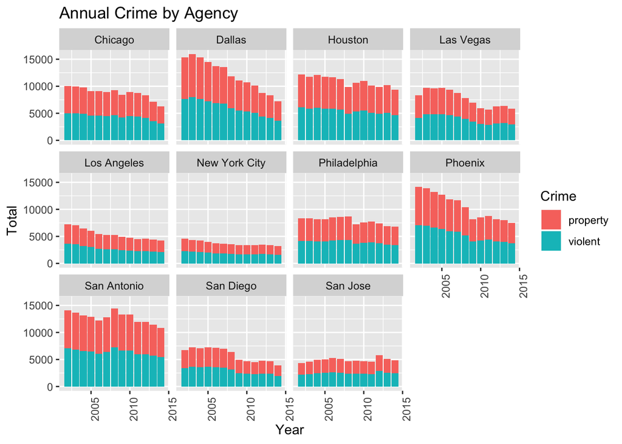

```r
ggplot(crimes, aes(Year, Total)) + geom_bar(stat = "identity", aes(fill = Crime)) + facet_wrap(.~Agency) + theme(axis.text.x = element_text(angle = 90, hjust = 1)) + labs(title = "Annual Crime by Agency")
```

#### Overview - Animation

The following plot was created using the gganimate extension for ggplot2. It illustrates change in crime rates for each agency over time.

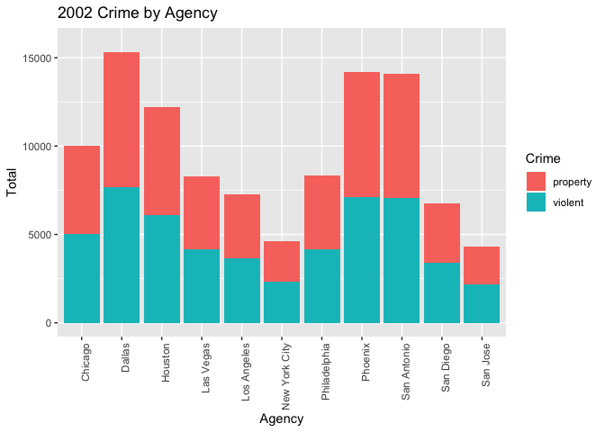

```r
c <- ggplot(crimes, aes(Agency, Total)) + geom_bar(stat = "identity", aes(fill = Crime)) + theme(axis.text.x = element_text(angle = 90, hjust = 1)) + transition_time(Year) + ease_aes('linear') + labs(title = "{frame_time} Crime by Agency", x = "Agency")
animate(c)
```

#### Crime Comparison

Stop-and-frisk policies were extremely biased and resulted in lasting repercussions. Despite this, advocates for the practice claim that it was successful in reducing crime. **We look at the crime statistics for NYC compared to other major cities over the same timeframe to see if these claims are accurate.**  
Looking at the plot below, we see that the change in NYC crime rates is comparable to changes in other cities over the same time period. In fact, NYC crime rate seems to decrease at a slower rate than most other cities; for example, Dallas and Phoenix saw a much more drastic decrease in crime than New York City did. Other research has also confirmed that [stop-and-frisk had no impact on crime in New York City](https://www.scribd.com/document/326789746/Fact-Sheet-Stop-and-Frisk-s-Effect-on-Crime-in-New-York-City).

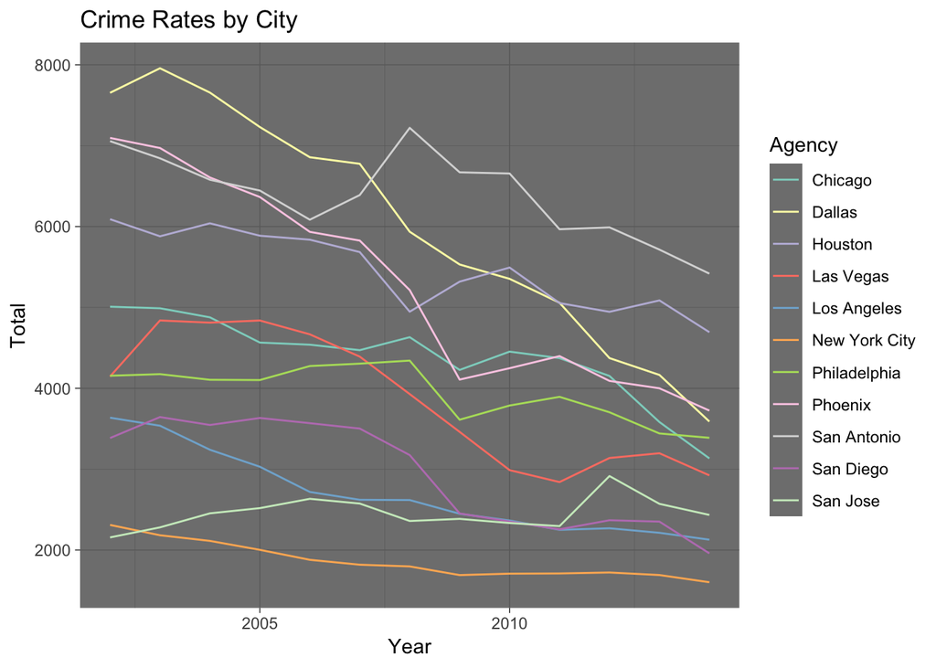

```r
#nyc crime rate over time (not plotted)
nyc <- ggplot(subset(crimes,Agency %in% "New York City")) +
  geom_line(aes(Year, Total)) +
  labs(title = "NYC Crime Rates over Time", x = "Year")

#crime rates for all cities over time
byagency <- ggplot(crimes) +
  geom_line(aes(Year, Total, color=Agency)) +
  labs(title = "Crime Rates by City", x = "Year") +
  scale_color_brewer(palette="Set3") + theme_dark()
#to plot charts together: grid.arrange(nyc, byagency, nrow = 1)
byagency
```